# Random Forests for Survival Analysis and High-Dimensional Data: R Example

Sarah Formentini, Yifan Cui, and Ruoqing Zhu

Last Updated: January 29, 2020

Abstract

This is one of the two supplementary `R` files for Random Forests for Survival Analysis and High-Dimensional Data in Springer Handbook of Engineering Statistics.

# Setup

## Install RLT from GitHub

```r
  #Installing RLT
  library(devtools)
  install_github("teazrq/RLT")
  library(RLT)
```

# High-Dimensional Example

## Load the data

Pull breast cancer data from the `.Rdata` file in the data folder. `R` code for pulling data from the NIH official website is provided in `Pull Data.R`. Here, we directly load the `.Rdata` file.

```r
  load("Data/GSE2034.Rdata")
  Data <- data.frame(X,Y=Y,Censor=Censor)
```

## Initial Feature Screening: Marginal Screening and Gene Signature

Run univariate Cox proportional hazards to find the variables with the most significant marginal relationship to survival.

```r
  weights <- numeric(dim(X)[2])
  for(i in 1:dim(X)[2]){
    weights[i] <- summary(coxph(Surv(Y, Censor)~X[,i]))$coefficients[5]
  }

  topX <- colnames(X)[order(weights)[1:500]]
```

The `Gene_signature.txt` file contains a list of the 76 variables included in the gene signature from Wang et al. (2005)

```r
  Gene_signature <- read.table("Data/Gene_signature.txt", header=TRUE, quote="\"", stringsAsFactors=FALSE)
```

We combine the marginal screening and signature variables and create a reduced data matrix.

```r
  combX <- unique(c(topX, Gene_signature$X))
  Xr <- X[,colnames(X) %in% combX]
  Data <- data.frame(Xr, "ER" = GSE2034_Clinical$`ER Status`, "Y" = Y, "Censor" = Censor)
  Xr <- Data[,-c(554:555)]
```

## Data Exploration

Fit two initial survival functions based on ER status, which Wang et al. (2005) used to stratify their data.

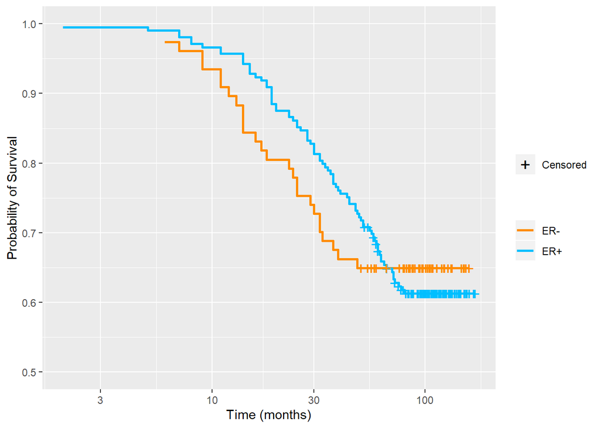

```r
  ERp<-survfit(Surv(Y,Censor)~1, data=Data[GSE2034_Clinical$`ER Status`=="ER+",])
  ERn<-survfit(Surv(Y,Censor)~1, data=Data[GSE2034_Clinical$`ER Status`=="ER-",])
  plot_frame <- data.frame(Time = c(ERp$time,ERn$time), Survival = c(ERp$surv,ERn$surv),
                           C = c(ifelse(ERp$n.censor>0,"Censored",NA),ifelse(ERn$n.censor>0,"Censored",NA)),
                           ER = c(rep("ER+",length(ERp$time)),rep("ER-",length(ERn$time))))

  ggplot(plot_frame,aes(x=Time,y=Survival)) +
    geom_step(aes(x=Time,y=Survival,col=ER),size=1,show.legend = TRUE) +
    scale_shape_manual(na.translate=FALSE,values="+") +
    geom_point(aes(shape=C,col=ER),size=5,na.rm = TRUE,show.legend = TRUE, position = "jitter") +
    scale_color_manual(values=c("darkorange","deepskyblue")) +
    xlab("Time (months)") +
    ylab("Probability of Survival") +
    guides(col = guide_legend(title = "", override.aes = list( shape='')),
           shape = guide_legend(title = "", override.aes = list(linetype = 0))) +
    ylim(0.5,1)+scale_x_log10()
```

```r
  ggsave("Results/GSE2034_MargbyER.png")
```

The number of failures and failure rate:

```r
  sum(Censor)
```

```
## [1] 107
```

```r
  sum(Censor)/length(Censor)
```

```
## [1] 0.3741259
```

## Model Fitting using Random Forests

Parameters tested for optimal model.

```r
  n = nrow(Xr)
  p = ncol(Xr)

  param_tunings <- expand.grid(mtry = c(sqrt(p), p/3, p),
                               nmin = c(1, log(n), n^(1/3)),
                   split.rule = c("suplogrank","logrank"),
                   split.gen=c("best","random"))
  param_tunings$oob_err <- NA
```

We tune the model by running through all possible parameter combinations. For computational reasons, we use the out-of-bag c-index as the selection criterion.

```r
  library(parallel)
  ncores = detectCores()

  for(i in 1:dim(param_tunings)[1])
  {
    cat(paste("Setting ", i, " ... \n"))
    set.seed(2+i)

    fit_ops <- RLT(Xr, Y, Censor, ntrees = 20000,
                   nmin = param_tunings$nmin[i],
                   mtry = param_tunings$mtry[i],
                   split.gen = param_tunings$split.gen[i],
                   split.rule = as.character(param_tunings$split.rule[i]),
                   nsplit = ifelse(param_tunings$split.gen[i]=="best", 0, 1),
                   ncores = ncores)

    param_tunings$oob_err[i]<-fit_ops$cindex

  }
```

The optimal parameters

```r
  besttunings = param_tunings[which.max(param_tunings$oob_err), ]

  mtry_opt <- besttunings$mtry
  nmin_opt <- besttunings$nmin
  splitgen_opt <- besttunings$split.gen
  splitrule_opt <- besttunings$split.rule

  param_tunings
```

```
##         mtry     nmin split.rule split.gen   oob_err
## 1   23.51595 1.000000 suplogrank      best 0.7300565
## 2  184.33333 1.000000 suplogrank      best 0.7109562
## 3  553.00000 1.000000 suplogrank      best 0.7057951
## 4   23.51595 5.655992 suplogrank      best 0.7289999
## 5  184.33333 5.655992 suplogrank      best 0.7130288
## 6  553.00000 5.655992 suplogrank      best 0.7107530
## 7   23.51595 6.588532 suplogrank      best 0.7296907
## 8  184.33333 6.588532 suplogrank      best 0.7142073
## 9  553.00000 6.588532 suplogrank      best 0.7107530
## 10  23.51595 1.000000    logrank      best 0.7280245
## 11 184.33333 1.000000    logrank      best 0.7091275
## 12 553.00000 1.000000    logrank      best 0.7042508
## 13  23.51595 5.655992    logrank      best 0.7289999
## 14 184.33333 5.655992    logrank      best 0.7128256
```

[output cut: 22 more lines]

```r
  mtry_opt
```

```
## [1] 184.3333
```

```r
  nmin_opt
```

```
## [1] 1
```

```r
  splitgen_opt
```

```
## [1] random
## Levels: best random
```

```r
  splitrule_opt
```

```
## [1] logrank
## Levels: suplogrank logrank
```

```r
  max(param_tunings$oob_err)/min(param_tunings$oob_err)
```

```
## [1] 1.048299
```

```r
  (1-min(param_tunings$oob_err))/(1-max(param_tunings$oob_err))
```

```
## [1] 1.129959
```

We fit the optimal model. Please note that due to the randomness of random forests, we may end up with slightly different results each time this is refitted. The best strategy is to use a large number of trees or set a random seed.

```r
  library(parallel)
  ncores = detectCores()
  fit_opt <- RLT(Xr, Y, Censor, ntrees = 20000, nmin = nmin_opt, mtry = mtry_opt,
                 nsplit = ifelse(splitgen_opt=="best",0,1),
                 split.gen = as.character(splitgen_opt),
                 split.rule = as.character(splitrule_opt),
                 importance = TRUE, ncores = ncores)
```

## Variable importance

Finding the top variable

```r
  VI1 <- colnames(Xr)[fit_opt$VarImp==max(fit_opt$VarImp)][1]
  VI1
```

```
## [1] "X219478_at"
```

Plotting the top 40 variable importance

```r
  VI <- data.frame("id" = c(1:p), "variable" = substring(colnames(Xr), 2),
                   "vi" = fit_opt$VarImp, "signature" = c(colnames(Xr)) %in% paste0("X",Gene_signature$X))
  VI <- VI[order(VI$vi),]
  VI$ord <- c(1:(dim(Xr)[2]))
  VI$variable <- factor(VI$variable, levels = VI$variable[order(VI$vi)])
  VI$color <- c(dim(VI)[1]:1) %in% c(1:40)
  head(VI)
```

```
##      id    variable            vi signature ord color
## 178 178   206295_at -5.001656e-05      TRUE   1 FALSE
## 166 166 205842_s_at -3.939649e-05     FALSE   2 FALSE
## 235 235   209523_at -3.527684e-05     FALSE   3 FALSE
## 372 372   215510_at -3.407290e-05      TRUE   4 FALSE
## 233 233 209499_x_at -3.292053e-05     FALSE   5 FALSE
## 58   58   202240_at -2.963698e-05      TRUE   6 FALSE
```

```r
  tail(VI)
```

```
##      id    variable           vi signature ord color
## 177 177   206205_at 0.0007887578     FALSE 548  TRUE
## 83   83 202998_s_at 0.0007915011     FALSE 549  TRUE
## 474 474 219312_s_at 0.0008388462     FALSE 550  TRUE
## 111 111 204015_s_at 0.0008893620      TRUE 551  TRUE
## 433 433   218252_at 0.0010645737     FALSE 552  TRUE
## 478 478   219478_at 0.0012648174     FALSE 553  TRUE
```

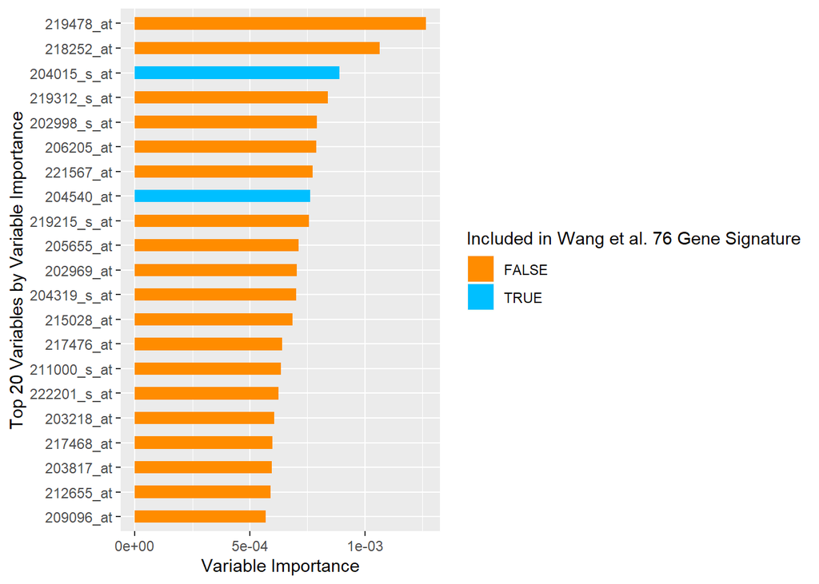

```r
  ggplot(VI[(dim(VI)[1]-20):dim(VI)[1],],aes(x=variable,y=vi,fill=signature)) +
    geom_col(width = 0.5,show.legend = TRUE) +
    scale_fill_manual(values=c("darkorange","deepskyblue")) +
    ylab("Variable Importance")+xlab("Top 20 Variables by Variable Importance") +
    coord_flip() +
    guides(fill = guide_legend(title = "Included in Wang et al. 76 Gene Signature"))
```

```r
  ggsave("Results/GSE2034_Top20VI.png")
```

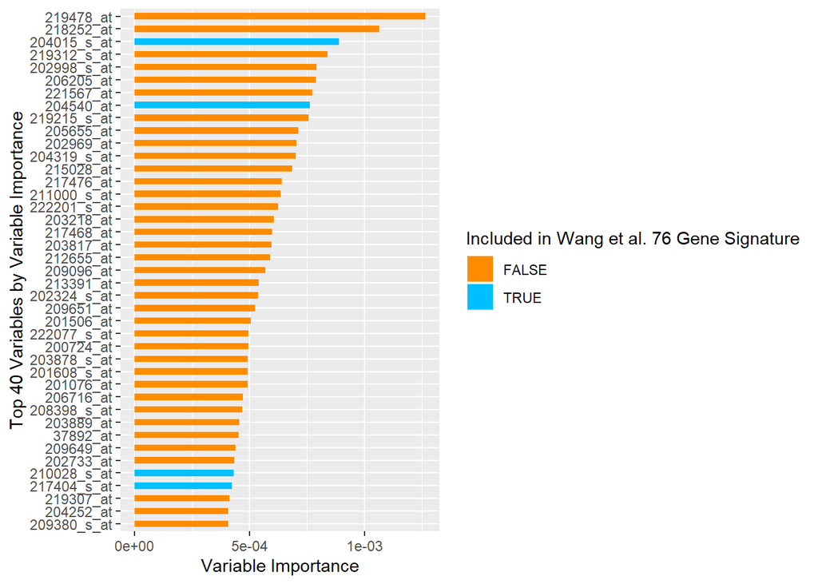

```r
  ggplot(VI[(dim(VI)[1]-40):dim(VI)[1],],aes(x=variable,y=vi,fill=signature)) +
    geom_col(width = 0.5,show.legend = TRUE) +
    scale_fill_manual(values=c("darkorange","deepskyblue")) +
    ylab("Variable Importance")+xlab("Top 40 Variables by Variable Importance") +
    coord_flip() +
    guides(fill = guide_legend(title = "Included in Wang et al. 76 Gene Signature"))
```

```r
  ggsave("Results/GSE2034_Top40VI.png")
```

## Plotting survival curves

Reshaping the survival curves so they can be easily plotted.

```r
  # calculate the survival curve since the output is hazard function
  surv_oob <- sapply(c(1:dim(fit_opt$OOBPrediction)[1]), function(i) exp(-cumsum(fit_opt$OOBPrediction[i,])))
  surv <- data.frame(fit_opt$timepoints,surv_oob)
  melted <- melt(surv,1)
  truth <- data.frame(subj=paste0("X",c(1:n)),Y=Data[,"Y"],ER=Data[,553],MaxVar=Data[,VI1])
  colnames(melted) <- c("Time", "Subject", "Probability")
  melted <- merge(melted, truth, by.x="Subject", by.y="subj", all.x=TRUE)
```

Pulling the subjects within ER+ and ER- which have the highest and lowest values of the most important variable.

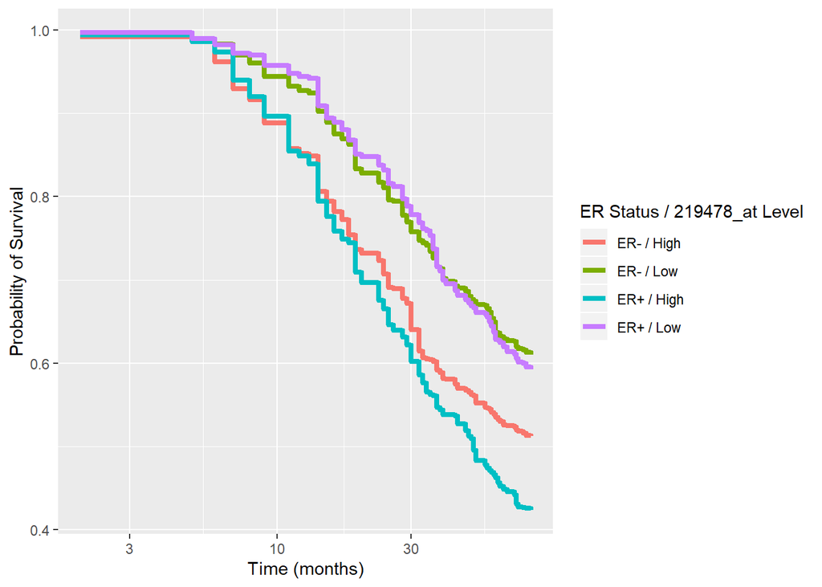

```r
  ERnL<-which(Data[[VI1]]==min(Data[[VI1]][Data$ER=="ER-"&Censor==1]))[1]
  ERpL<-which(Data[[VI1]]==min(Data[[VI1]][Data$ER=="ER+"&Censor==1]))[1]
  ERnH<-which(Data[[VI1]]==max(Data[[VI1]][Data$ER=="ER-"&Censor==1]))[1]
  ERpH<-which(Data[[VI1]]==max(Data[[VI1]][Data$ER=="ER+"&Censor==1]))[1]

  Lev <- data.frame(Subject=paste0("X",c(ERnL,ERpL,ERnH,ERpH)), Level=c("ER- / Low","ER+ / Low","ER- / High","ER+ / High"))

  melted2 <- melted[melted$Subject %in% paste0("X",c(ERnL,ERpL,ERnH,ERpH)),]
  melted2$Level <- sapply(as.character(melted2$Subject),function(s) Lev$Level[Lev$Subject==s])

  ggplot(melted2,aes(x=Time,y=Probability)) +
    geom_step(aes(group=Subject,col=Level),show.legend = TRUE,size=1.5) +
    ylab("Probability of Survival")+xlab("Time (months)") +
    scale_x_log10() +
    guides(col = guide_legend(title = paste0("ER Status / ",substring(VI1,2) ," Level")))
```

```r
  ggsave("Results/GSE2034_TestPredsStrat.png")
```

# References

Wang, Yixin, Jan G.M. Klijn, Yi Zhang, Anieta M. Sieuwerts, Maxime P. Look, Fei Yang, Dmitri Talantov, et al. 2005. “Gene-expression profiles to predict distant metastasis of lymph-node-negative primary breast cancer.” *Lancet* 365: 671–79. doi:10.1016/S0140-6736(05)70933-8.